# EcoPlotsAPI

Arun Singh Ramesh[^1]

28/09/2023

## EcoPlots API example

The example code shown here is designed to give you an experience at downloading, analyzing and visualising any dataset archived on the TERN EcoPlots https://ecoplots.tern.org.au/. EcoPlots contains plot-based ecology data from different sources to enable integrated search and access to data based on different jurisdiction, data sources, feature types, parameters and temporal extent.

# General preparations

### Set your working directory

This gets you started with storing your files and r scripts.

```r
#setwd("C:/Users/uqasin21") # Note that your path will be different
```

### Load libraries

If you do not have the following packages downloaded, you can install them using the function `install.packages`, with the name of the package as an argument in quotations.

```r
library(tidyverse)
library(httr)
library(ggpubr)
library(gridExtra)
```

# Load and explore the data

At this point, you should have your Ecoplots search query from the EcoPlots API Query dash board (https://ecoplots.tern.org.au/discovery).

*Important* Make sure to download your API key from the website (https://account-test.tern.org.au/authenticated_user/apikeys) Once you have your API code extracted you can start using the query request

```r
headers = c(
  'X-Api-Key' = 'your-api-key',
  'Content-Type' = 'application/json'
)

body = '{
  "query": {
    "dataset": [
      "http://linked.data.gov.au/dataset/bdbsa"
    ],
    "observed_property": [
      "http://linked.data.gov.au/def/tern-cv/fc2dcb5b-94a5-440f-9104-efaa640246cc",
      "http://linked.data.gov.au/def/tern-cv/56195246-ec5d-4050-a1c6-af786fbec715",
      "http://linked.data.gov.au/def/tern-cv/800cf33b-1c44-435d-89bd-5d80e3e8aba1"
    ],
    "feature_type": [
      "http://linked.data.gov.au/def/tern-cv/226a127b-7248-476a-84ad-0412a5e3af52"
    ]
  }
}';

res <- VERB("POST", url = "https://ecoplots-test.tern.org.au/api/v1.0/data/bdbsa?dformat=csv", body = body, add_headers(headers))

cat(content(res, 'text'))

df <- read.table(text = content(res, 'text'), sep =",", header = TRUE, stringsAsFactors = FALSE)
```

# **Explore your data frame and do simple stats**

First step is to explore the data frame and organise it to suite your research needs. In this example dataset, I have queried results for body mass of mammals from the BDBSA data source. Let us explore and see what infornation can we derive.

```r
#data exploration and wrangling
head(df)
```

|  | datasetTitle | projectTitle | siteName | parentSiteName | latitude_Degree | longitude_Degree | altitude_Metre | siteVisitName | siteVisitStartDate | siteVisitEndDate | featureType | featureId | scientificName | scientificName.1 | scientificNameResultTime | scientificNameMethod | bodyMass_gram | bodyMassResultTime | bodyMassMethod |
| --- | --- | --- | --- | --- | --- | --- | --- | --- | --- | --- | --- | --- | --- | --- | --- | --- | --- | --- | --- |
| 1 | BDBSA | South Olary Plains | OP00101-11167 | N/A | -32.60902 | 139.8556 | 500 | 19920928 | 1992-09-28T00:00:00 | 1992-09-28T00:00:00 | mammal individual | http://linked.data.gov.au/dataset/bdbsa/mammal_ind_id-1365245 | Chalinolobus gouldii (Gray, 1841) | Chalinolobus gouldii (Gray, 1841) | 1992-09-30T00:00:00 | https://linked.data.gov.au/def/bdbsa-cv/d0d25612-95cc-40eb-a81a-603f9c0fbecf | 18.0 | 1992-09-30T00:00:00 | https://linked.data.gov.au/def/bdbsa-cv/d0d25612-95cc-40eb-a81a-603f9c0fbecf |
| 2 | BDBSA | Anangu Pitjantjatjara Yankunytjatjara Lands | WW00501-11572 | N/A | -26.31353 | 130.4010 | 700 | 19930506 | 1993-05-06T00:00:00 | 1993-05-06T00:00:00 | mammal individual | http://linked.data.gov.au/dataset/bdbsa/mammal_ind_id-1359439 | Pseudomys hermannsburgensis (Waite, 1896) | Pseudomys hermannsburgensis (Waite, 1896) | 1993-05-07T00:00:00 | https://linked.data.gov.au/def/bdbsa-cv/d0d25612-95cc-40eb-a81a-603f9c0fbecf | N/A | N/A | N/A |
| 3 | BDBSA | Anangu Pitjantjatjara Yankunytjatjara Lands | WW00501-11572 | N/A | -26.31353 | 130.4010 | 700 | 19930506 | 1993-05-06T00:00:00 | 1993-05-06T00:00:00 | mammal individual | http://linked.data.gov.au/dataset/bdbsa/mammal_ind_id-1368606 | Mus domesticus Rutty, 1772 | Mus domesticus Rutty, 1772 | 1993-05-06T00:00:00 | https://linked.data.gov.au/def/bdbsa-cv/d0d25612-95cc-40eb-a81a-603f9c0fbecf | 14.0 | 1993-05-06T00:00:00 | https://linked.data.gov.au/def/bdbsa-cv/d0d25612-95cc-40eb-a81a-603f9c0fbecf |
| 4 | BDBSA | Anangu Pitjantjatjara Yankunytjatjara Lands | WW00501-11572 | N/A | -26.31353 | 130.4010 | 700 | 19930506 | 1993-05-06T00:00:00 | 1993-05-06T00:00:00 | mammal individual | http://linked.data.gov.au/dataset/bdbsa/mammal_ind_id-1370340 | Mus domesticus Rutty, 1772 | Mus domesticus Rutty, 1772 | 1993-05-05T00:00:00 | https://linked.data.gov.au/def/bdbsa-cv/d0d25612-95cc-40eb-a81a-603f9c0fbecf | 11.0 | 1993-05-05T00:00:00 | https://linked.data.gov.au/def/bdbsa-cv/d0d25612-95cc-40eb-a81a-603f9c0fbecf |
| 5 | BDBSA | Anangu Pitjantjatjara Yankunytjatjara Lands | WW00501-11572 | N/A | -26.31353 | 130.4010 | 700 | 19930506 | 1993-05-06T00:00:00 | 1993-05-06T00:00:00 | mammal individual | http://linked.data.gov.au/dataset/bdbsa/mammal_ind_id-1370341 | Pseudomys hermannsburgensis (Waite, 1896) | Pseudomys hermannsburgensis (Waite, 1896) | 1993-05-08T00:00:00 | https://linked.data.gov.au/def/bdbsa-cv/d0d25612-95cc-40eb-a81a-603f9c0fbecf | N/A | N/A | N/A |
| 6 | BDBSA | Anangu Pitjantjatjara Yankunytjatjara Lands | BH00101-11542 | N/A | -27.13268 | 132.8595 | 510 | 19930318 | 1993-03-18T00:00:00 | 1993-03-18T00:00:00 | mammal individual | http://linked.data.gov.au/dataset/bdbsa/mammal_ind_id-1356431 | Mus domesticus Rutty, 1772 | Mus domesticus Rutty, 1772 | 1993-03-17T00:00:00 | https://linked.data.gov.au/def/bdbsa-cv/d0d25612-95cc-40eb-a81a-603f9c0fbecf | 9.0 | 1993-03-17T00:00:00 | https://linked.data.gov.au/def/bdbsa-cv/d0d25612-95cc-40eb-a81a-603f9c0fbecf |

```r
tail(df)
```

|  | datasetTitle | projectTitle | siteName | parentSiteName | latitude_Degree | longitude_Degree | altitude_Metre | siteVisitName | siteVisitStartDate | siteVisitEndDate | featureType | featureId | scientificName | scientificName.1 | scientificNameResultTime | scientificNameMethod | bodyMass_gram | bodyMassResultTime | bodyMassMethod |
| --- | --- | --- | --- | --- | --- | --- | --- | --- | --- | --- | --- | --- | --- | --- | --- | --- | --- | --- | --- |
| 32898 | BDBSA | Prey response to feral cat control on Kangaroo Island, SA | NA | N/A | -35.78600 | 137.9682 | NA | NA |  |  | mammal individual | http://linked.data.gov.au/dataset/bdbsa/mammal_ind_id-81125 | Mus musculus Linnaeus, 1766 | Mus musculus Linnaeus, 1766 | 2017-04-06T00:00:00 | https://linked.data.gov.au/def/bdbsa-cv/d0d25612-95cc-40eb-a81a-603f9c0fbecf | 11.0 | 2017-04-06T00:00:00 | https://linked.data.gov.au/def/bdbsa-cv/d0d25612-95cc-40eb-a81a-603f9c0fbecf |
| 32899 | BDBSA | Prey response to feral cat control on Kangaroo Island, SA | NA | N/A | -35.79319 | 137.5996 | NA | NA |  |  | mammal individual | http://linked.data.gov.au/dataset/bdbsa/mammal_ind_id-81127 | Mus musculus Linnaeus, 1766 | Mus musculus Linnaeus, 1766 | 2017-04-11T00:00:00 | https://linked.data.gov.au/def/bdbsa-cv/d0d25612-95cc-40eb-a81a-603f9c0fbecf | 10.0 | 2017-04-11T00:00:00 | https://linked.data.gov.au/def/bdbsa-cv/d0d25612-95cc-40eb-a81a-603f9c0fbecf |
| 32900 | BDBSA | Prey response to feral cat control on Kangaroo Island, SA | NA | N/A | -35.79319 | 137.5996 | NA | NA |  |  | mammal individual | http://linked.data.gov.au/dataset/bdbsa/mammal_ind_id-81128 | Mus musculus Linnaeus, 1766 | Mus musculus Linnaeus, 1766 | 2017-04-12T00:00:00 | https://linked.data.gov.au/def/bdbsa-cv/d0d25612-95cc-40eb-a81a-603f9c0fbecf | 11.0 | 2017-04-12T00:00:00 | https://linked.data.gov.au/def/bdbsa-cv/d0d25612-95cc-40eb-a81a-603f9c0fbecf |
| 32901 | BDBSA | EBS Ecology Flora & Fauna Survey South Australia | NA | N/A | -30.15325 | 133.5065 | NA | NA |  |  | mammal individual | http://linked.data.gov.au/dataset/bdbsa/mammal_ind_id-90090 | Sminthopsis macroura (Gould, 1845) | Sminthopsis macroura (Gould, 1845) | 2015-09-23T00:00:00 | https://linked.data.gov.au/def/bdbsa-cv/d0d25612-95cc-40eb-a81a-603f9c0fbecf | N/A | N/A | N/A |
| 32902 | BDBSA | EBS Ecology Flora & Fauna Survey South Australia | NA | N/A | -30.19970 | 133.5043 | NA | NA |  |  | mammal individual | http://linked.data.gov.au/dataset/bdbsa/mammal_ind_id-90100 | Planigale tenuirostris Troughton, 1928 | Planigale tenuirostris Troughton, 1928 | 2015-09-26T00:00:00 | https://linked.data.gov.au/def/bdbsa-cv/d0d25612-95cc-40eb-a81a-603f9c0fbecf | N/A | N/A | N/A |
| 32903 | BDBSA | EBS Ecology Flora & Fauna Survey South Australia | NA | N/A | -30.10849 | 133.5870 | NA | NA |  |  | mammal individual | http://linked.data.gov.au/dataset/bdbsa/mammal_ind_id-90801 | Sminthopsis macroura (Gould, 1845) | Sminthopsis macroura (Gould, 1845) | 2015-09-20T00:00:00 | https://linked.data.gov.au/def/bdbsa-cv/d0d25612-95cc-40eb-a81a-603f9c0fbecf | N/A | N/A | N/A |

```r
summary(df)
```

```
##  datasetTitle       projectTitle         siteName         parentSiteName
##  Length:32903       Length:32903       Length:32903       Length:32903
##  Class :character   Class :character   Class :character   Class :character
##  Mode  :character   Mode  :character   Mode  :character   Mode  :character
##
##
##
##
##  latitude_Degree  longitude_Degree altitude_Metre   siteVisitName
##  Min.   :-38.05   Min.   :129.0    Min.   : -52.0   Min.   :19830101
##  1st Qu.:-35.76   1st Qu.:136.8    1st Qu.:  34.0   1st Qu.:19990320
##  Median :-35.54   Median :137.2    Median :  85.0   Median :20011023
##  Mean   :-33.48   Mean   :137.0    Mean   : 177.8   Mean   :20024299
##  3rd Qu.:-30.50   3rd Qu.:138.2    3rd Qu.: 270.0   3rd Qu.:20051114
##  Max.   :-25.69   Max.   :141.2    Max.   :1000.0   Max.   :20160901
##                                    NA's   :25799    NA's   :20243
##  siteVisitStartDate siteVisitEndDate   featureType         featureId
##  Length:32903       Length:32903       Length:32903       Length:32903
##  Class :character   Class :character   Class :character   Class :character
##  Mode  :character   Mode  :character   Mode  :character   Mode  :character
##
##
##
##
##  scientificName     scientificName.1   scientificNameResultTime
##  Length:32903       Length:32903       Length:32903
##  Class :character   Class :character   Class :character
##  Mode  :character   Mode  :character   Mode  :character
##
##
##
##
##  scientificNameMethod bodyMass_gram      bodyMassResultTime bodyMassMethod
##  Length:32903         Length:32903       Length:32903       Length:32903
##  Class :character     Class :character   Class :character   Class :character
##  Mode  :character     Mode  :character   Mode  :character   Mode  :character
##
##
##
##
```

It looks like the dataset has many vectors either as a categorical or numeric vector. We need to organise the dataframe and store the categorical values as a factor.

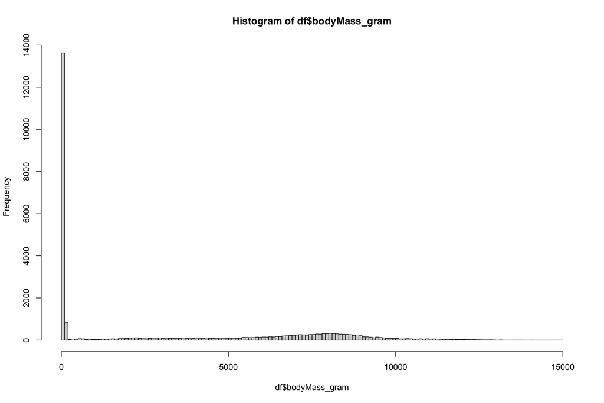

```r
#convert your numerical values to numeric and categorical values into factor levels
df$bodyMass_gram<- as.numeric(df$bodyMass_gram)
df$scientificName<- as.factor(df$scientificName)

# visualise the general distribution of your response variable (body mass)
hist(df$bodyMass_gram, breaks = 150)
```

It looks like majority of the dataset contains body mass distribution of mammals below 300g. Here we subset the data frame to represent body mass below 50g for example and then see if the distribution is normal.

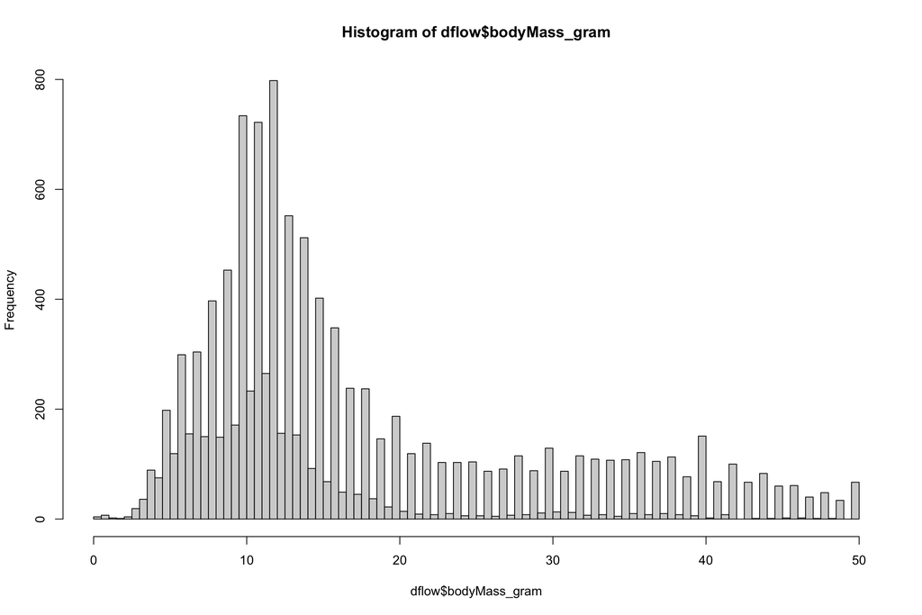

```r
#subset
dflow<- subset(df, bodyMass_gram<=50)
hist(dflow$bodyMass_gram, breaks = 100)
```

# **Data Visualisation**

For the first instance, let us visualise a relation between body mass with elevation

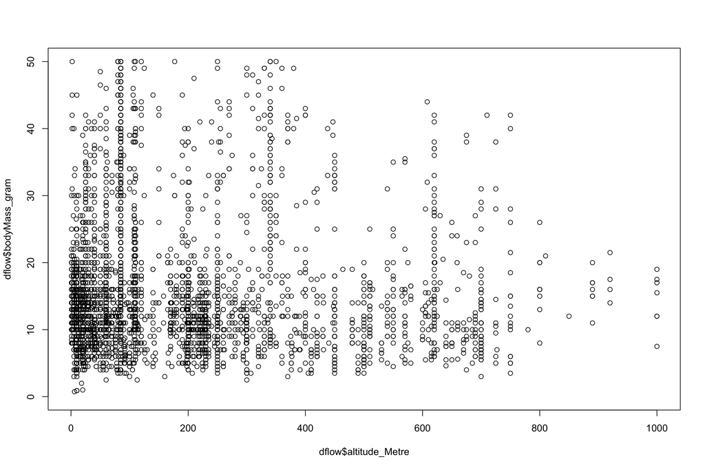

```r
plot(dflow$bodyMass_gram~dflow$altitude_Metre)
```

As you can see the data is scattered all over with higher point clouds at lower elevation sites. Let visualise with a regression line and see how the slope of the relationship changes with elevation.

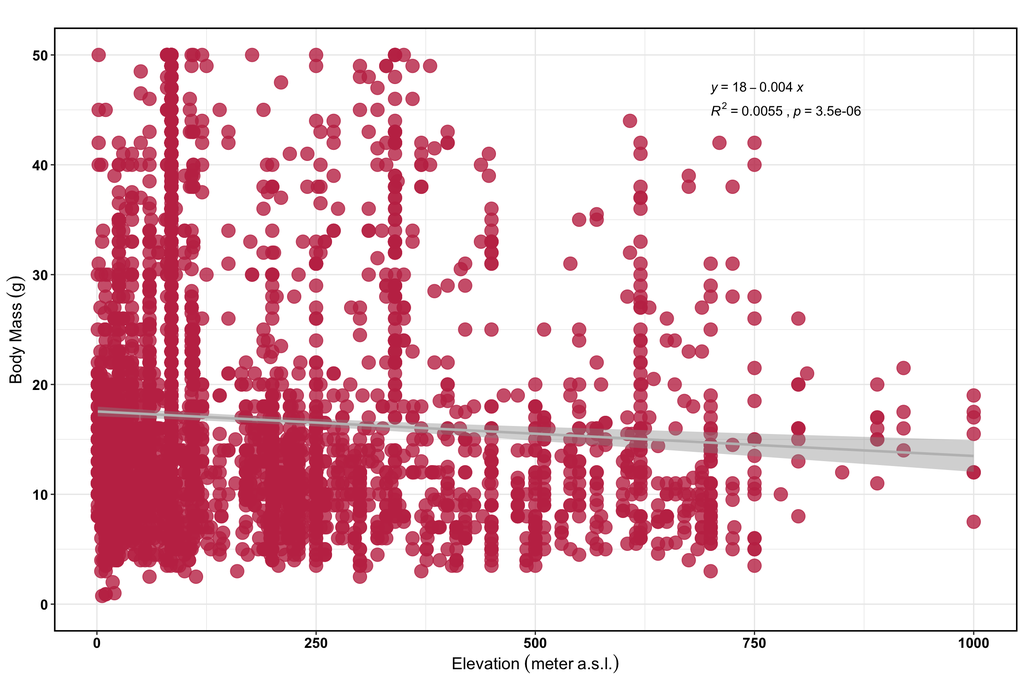

```r
#fancy data visualisation
library(ggpubr)

l1<-ggscatter(dflow, x = "altitude_Metre", y = "bodyMass_gram",
              color = "#C33453", pch=19, size=5,alpha=0.8)+ggtitle("")+
  stat_cor(aes(label = paste(..rr.label.., ..p.label.., sep = "~`,`~")),label.y = 45, label.x = 700, size=4)+stat_smooth(se=TRUE, formula = y~x, color="grey")+
  stat_regline_equation(label.y =47 , label.x = 700, size=4)+
  xlab(expression(Elevation~(meter~a.s.l.)))+ ylab(expression(Body~Mass~("g")))+ theme_bw()

l1+ theme(axis.text.y = element_text(colour = "black", size = 12, face = "bold"),
          axis.text.x = element_text(colour = "black", face = "bold", size = 12),
          legend.text = element_text(size = 12, face ="bold", colour ="black"),
          legend.position = "top", axis.title.y = element_text(face = "bold", size = 14),
          axis.title.x = element_text(face = "bold", size = 14, colour = "black"),
          legend.title = element_text(size = 14, colour = "black", face = "bold"),
          panel.background = element_blank(), panel.border = element_rect(colour = "black", fill = NA, size = 1.2),
          legend.key=element_blank())
```

As you can see there is a weak but negative slope, suggesting that majority of large mammals are found in the lower elevation sites.

# **Body mass summary at Site/Species level**

Now that we have a relation of body mass with elevation. Let us normalise the data and calculate the trends in body size across different bioregions. In this example we use two contrasting biomes- a coast versus an inland desert.

```r
#aggregate biomass by Species, Project and Site
dflow$projectTitle<- as.factor(dflow$projectTitle)
dflow$siteName<- as.factor(dflow$siteName)

library(tidyverse)
library(gridExtra)

dflow%>%
  group_by(siteName,projectTitle,scientificName)%>%
  summarize(bodyMass_gram=sum(bodyMass_gram,na.rm=TRUE))->summed_species_level_biomass

# let us see the body mass averaged for each species
with(summed_species_level_biomass, tapply(bodyMass_gram, c(scientificName), mean))
```

```
##                         Antechinomys laniger (Gould, 1856)
##                                                  99.368750
##                Antechinomys laniger spenceri (Gould, 1856)
##                                                4095.000000
##  Antechinus agilis Dickman, Parnaby, Crowther & King, 1998
##                                                 936.000000
##                     Antechinus flavipes (Waterhouse, 1838)
##                                                 493.588235
##                        Antechinus minimus (Geoffroy, 1803)
##                                                2387.000000
##                      Arctocephalus tropicalis (Gray, 1872)
##                                                  56.900000
##                         Austronomus australis (Gray, 1838)
##                                                  36.500000
##                           Bettongia penicillata Gray, 1837
##                                                         NA
##                   Bettongia penicillata ogilbyi Gray, 1837
##                                                         NA
##                         Camelus dromedarius Linnaeus, 1758
##                                                         NA
##                        Cercartetus concinnus (Gould, 1845)
##                                                  58.982773
##                         Cercartetus lepidus (Thomas, 1888)
##                                                 141.400000
##                        Cercartetus nanus (Desmarest, 1818)
##                                                  63.522222
##                                            Cercartetus sp.
##                                                   8.000000
##                          Chalinolobus gouldii (Gray, 1841)
##                                                  43.542857
##                            Chalinolobus morio (Gray, 1841)
##                                                  21.826923
##                          Dasycercus byrnei (Spencer, 1896)
##                                                 883.000000
##                      Dasycercus cristicauda (Krefft, 1867)
##                                                         NA
##                      Dasycercus cristicauda (Thomas, 1905)
##                                                  25.500000
##             Dasycercus cristicauda hillieri (Thomas, 1905)
##                                                  36.833333
```

[output cut: 145 more lines]

```
##                                                   9.856667
##                       Vespadelus darlingtoni (Allen, 1933)
##                                                   6.500000
##    Vespadelus finlaysoni (Kitchener, Jones & Caputi, 1987)
##                                                   8.933333
##                          Vespadelus regulus (Thomas, 1906)
##                                                  12.125000
##                                             Vespadelus sp.
##                                                   7.842857
##                        Vespadelus vulturnus (Thomas, 1914)
##                                                   5.143750
##                                       VESPERTILIONIDAE sp.
##                                                         NA
##                             Vulpes vulpes (Linnaeus, 1758)
##                                                   0.750000
```

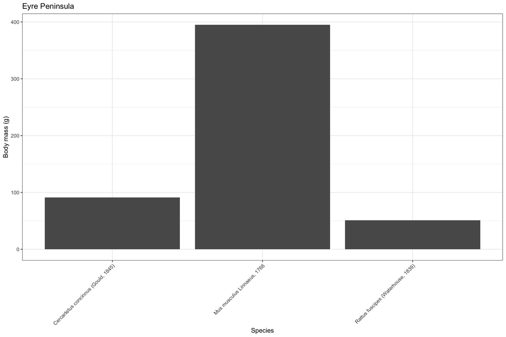

```r
#subset data for the project on Eyre Peninsula (coast) in SA

Eyre_Peninsula<- subset(summed_species_level_biomass, projectTitle=="Southern Eyre Peninsula")

#plot species biomass by Project location (one in coast versus inland desert)
#Lets look at the Coast
plot1<-ggplot(Eyre_Peninsula, aes(x = scientificName, y = bodyMass_gram))+ggtitle("Eyre Peninsula")+geom_col(position="dodge")+labs(x="Species",y="Body mass (g)")
p1<- plot1+theme_bw() +theme(axis.text.x = element_text(angle = 45, hjust = 1))
p1
```

There appears to be fewer species recorded from this Coast with the species *Mus musculus* accounting for the highest body mass.

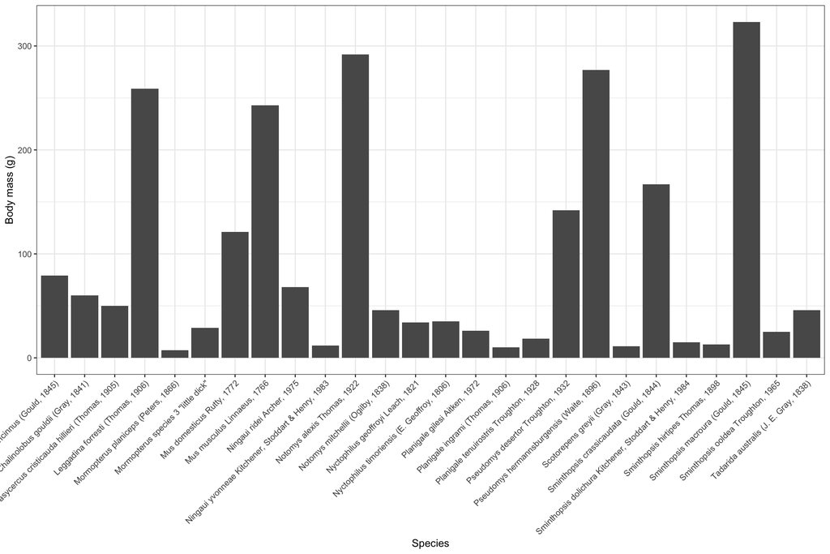

```r
#subset data for the Project on Sandy Desert in SA

Sandy_desert<-subset(summed_species_level_biomass,projectTitle=="Sandy Desert")

#plot species biomass by Project location (inland desert)

#Sandy desert
plot2<-ggplot(Sandy_desert, aes(x = scientificName, y = bodyMass_gram))+geom_col(position="dodge")+labs(x="Species",y="Body mass (g)")
p2<- plot2+theme_bw() +theme(axis.text.x = element_text(angle = 45, hjust = 1))
p2
```

# Summary

- We queried a dataset from the [TERN EcoPlots](https://ecoplots.tern.org.au/) from the BDBSA data source using the EcoPLots API query request.
- With a few simple steps we managed to input a dataframe in R and observed trends in mammal body size.
- We found variation in body mass with elevation and also found variation from the coast to the inland deserts in the SA region.

# References

[TERN EcoPlots- Terrestrial Ecosystem Research Network.](https://ecoplots.tern.org.au/)

[The Biological Databases of South Australia (BDBSA)](https://www.environment.sa.gov.au/topics/science/information-and-data/biological-databases-of-south-australia)

# Cite this example

This example is licensed under the Creative Commons Attribution 4.0 (CC-BY-4.0)

You can cite this example dataset for your research as: Singh Ramesh, A. 2023. An example to query an API request for CSV files from the TERN EcoPlots (BDBSA).https://ternaustralia.github.io/ecoplots-examples/

[^1]: TERN, a.singhramesh@uq.edu.au